# M2.859 - Visualización de datos aula 1

# **A5: Estudio de técnicas de visualización de datos (PEC2)**

Andres Ricardo Sanabria Garay

Mayo 2023

# Técnica de visualización Pyramid Chart

## Contenido

- Descripción
- Origen
- Funcionamiento
- Ejemplo de aplicación
- Conclusión

# 1 Descripción

El pyramid chart es un gráfico de una sola serie que no utiliza un eje. Representa los datos como porciones de un 100%, los segmentos individuales se suman para representar un todo. Por ejemplo, se puede mostrar la distribución de la población por edad y sexo, la estructura organizativa de una empresa o el proceso de aprendizaje según diferentes métodos.

# 2 Origen

El origen del gráfico de pirámide no está claro, pero se ha utilizado durante mucho tiempo para representar jerarquías o procesos.

# 3 Funcionamiento

Como su nombre lo indica se trata de una pirámide que representa un todo y se divide en secciones horizontales, cada una de las cuales representa una categoría y un porcentaje dentro de la distribución.

# 4 Ejemplo de aplicación

Utilizaremos un conjunto de datos relacionado con la catástrofe del Titanic, publicado por: KHASHAYAR BAGHIZADEH HOSSEINI, y que se encuentra disponible en la plataforma kaggle en el siguietne enlace:

https://www.kaggle.com/datasets/heptapod/titanic

Nuestro objetivo será utilizar la técnica de visualización de datos Pyramid Chart para ver la distribución de la edad de los sobrevivientes del Titanic.

A continuación realizamos la carga del dataset “Titanic”

```r
# Cargamos las librerías que utilizaremos

if(!require(ggplot2)){
    install.packages('ggplot2', repos='http://cran.us.r-project.org')
    library(ggplot2)
}
if(!require(dplyr)){
    install.packages('dplyr', repos='http://cran.us.r-project.org')
    library(dplyr)
}
# Cargamos el conjunto de datos
df_titanic_full <- read.csv("train_and_test2.csv", header = TRUE, sep = ",")
dim(df_titanic_full)
```

```
## [1] 1309   28
```

Dado que solo nos interesa el grupo de sobrevivientes filtraremos por este atributo, en el que 1 corresponde a que la persona sobrevivió y 0 que no.

```r
df_titanic_live <- subset(df_titanic_full, X2urvived == 1)
dim(df_titanic_live)
```

```
## [1] 342  28
```

Procedemos a categorizar los 342 sobrevivientes por edad de la siguiente manera: personas menores de 16 años, personas de 16 y menores de 30 años, personas de 30 y menores de 50 años, personas mayores de 50 años

```r
df_titanic_live$age_sur <- cut(df_titanic_live$Age, breaks = c(-Inf, 16, 30, 50, Inf),
                               labels = c("niños", "jovenes", "adultos", "mayores"))
summary(df_titanic_live$age_sur)
```

```
##   niños jovenes adultos mayores
##      55     163     102      22
```

Procedemos a generar el Pyramid Chart empleando la librería ggplot2

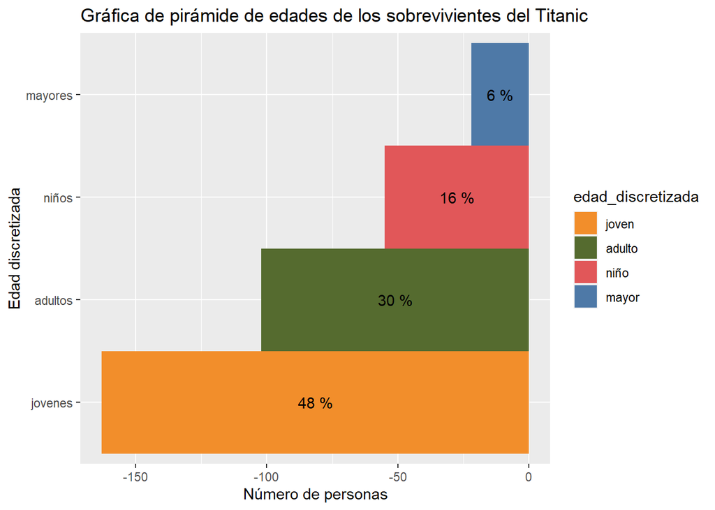

```r
# Crear un resumen de los datos por edad discretizada
resumen_edad <- aggregate(df_titanic_live$age_sur, by = list(df_titanic_live$age_sur), FUN = length)
colnames(resumen_edad) <- c("edad_discretizada", "conteo")

# Agregar una columna con los porcentajes
resumen_edad$porcentaje <- resumen_edad$conteo / sum(resumen_edad$conteo) * 100

# Ordenar el factor "edad_discretizada" por el porcentaje
resumen_edad$edad_discretizada <- factor(resumen_edad$edad_discretizada,
                                          levels = resumen_edad$edad_discretizada[order(resumen_edad$porcentaje, decreasing = TRUE)])

# Definir los valores de etiquetas y colores en el orden correspondiente
etiquetas <- c("joven", "adulto", "niño", "mayor")
colores <- c("#F28E2B", "#556B2F", "#E15759", "#4E79A7")

# Crear la gráfica de pirámide
ggplot(resumen_edad, aes(x = edad_discretizada, y = -conteo, fill = edad_discretizada)) +
  geom_bar(stat = "identity", position = "identity", width = 1) +
  scale_fill_manual(values = colores, labels = etiquetas) +
  geom_text(aes(label = paste(round(porcentaje), "%"), y = -conteo/2)) +
  ggtitle("Gráfica de pirámide de edades de los sobrevivientes del Titanic") +
  labs(x = "Edad discretizada", y = "Número de personas") +
  coord_flip()
```

# 5 Conclusión

Ha sido posible representar el porcentaje de sobrevivientes del desastre del Titanic por edad, mediante la técnica de Visualización Pyramid Chart, implementada con la ayuda de las librerías ggplot2 y dplyr en un entorno programado con R. Con esta herramienta podemos afirmar que de las 342 personas que sobrevivieron el 48% eran jóvenes (entre 16 y 30 años), el 30% eran adultos (entre 30 y 50 años), el 16% eran niños (menos de 16 años) y sólo el 6% eran mayores (personas con más de 50 años).